# Random Forest for Competing Risks Data: Part II (Example Data analysis using R)

## [8] Variable Selection using random forest

Although, the main function rfsrc() has the option to output variable importance and minimal depth, these measures can be separately computed using the fitted rfsrc object in var.select() function, which provides variable selection based on these features.

```r
 # perform variable selection based on minimal depth
 b = var.select( object = fit.rf, cause = 1, method = "md", ntree = 100, mtry = 2, verbose = F )

 #NOTE: This function implements random forest variable selection using tree minimal depth methodology
 #(Ishwaran et al., 2010). The option method allows for two different approaches:
 #1. method="md" (Invokes minimal depth variable selection) (preferred method),
 #2. method="vh" or method="vh.vimp" (Invokes variable hunting).

 # print variable importance and minimal depth values
 print(b$varselect)
```

```
##              depth  vimp.event.1  vimp.event.2  vimp.event.3
## surgery_ix    3.14 -0.0014069185  5.401909e-02  0.0155304912
## cigday2       3.75 -0.0010246583  5.633344e-03 -0.0051239774
## quityears2    3.79 -0.0083349157  5.845281e-03  0.0051114213
## hist2.ix      3.91 -0.0095772337  2.902567e-03  0.0039909412
## packyears2    4.02  0.0034109040  5.617082e-03  0.0044614748
## stage2.ix     4.02  0.0144114898  3.856763e-02  0.0027109170
## age.ix.cat    4.04 -0.0152396125  8.138480e-04  0.0011767681
## bmi           4.33 -0.0153980497  5.807440e-03  0.0031127804
## edu           4.42  0.0023948477  2.987714e-03  0.0082483622
## race.cat      4.48 -0.0014291058  1.081907e-03 -0.0014747634
## chemo_ix      4.80  0.0133317010  1.825293e-03  0.0069461151
## sex           4.97 -0.0026098403  1.563046e-03 -0.0031695856
## radiation_ix  5.12 -0.0002113046 -4.803669e-04  0.0057221485
## smkstatus2    5.23 -0.0065650592  8.879603e-04  0.0009351247
## USPSTF        5.25 -0.0024776742 -4.734015e-05  0.0046076795
## copd          5.43 -0.0042265518  1.158509e-03  0.0021820815
## ph            5.64 -0.0023605097  2.634606e-03 -0.0051433376
## fh            5.67 -0.0029547581  1.359144e-03  0.0095575434
```

```r
 print(b$topvars)
```

```
## [1] "surgery_ix" "cigday2"    "quityears2" "hist2.ix"   "packyears2" "stage2.ix"  "age.ix.cat"
```

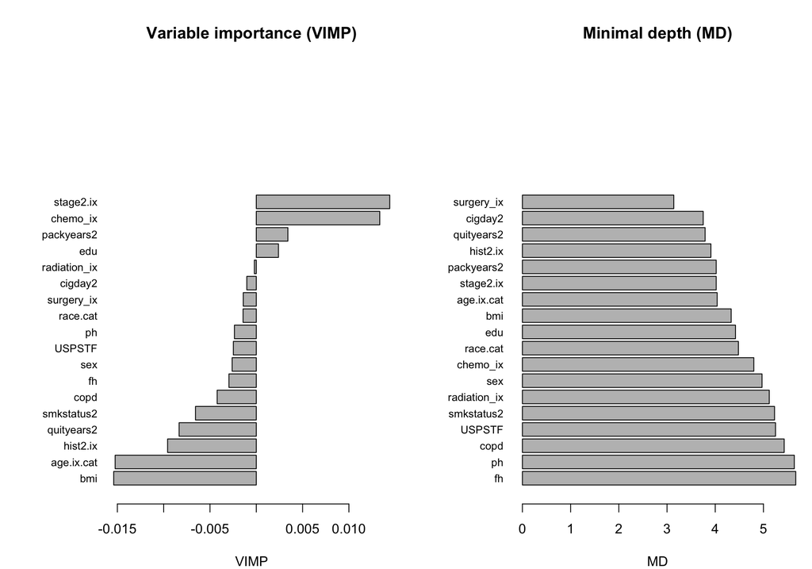

```r
 md = b$varselect$depth
 names(md) = rownames(b$varselect)

 # plot variable importance and minimal depth values

 par(mfrow = c(1,2), mar=c(4,7,4,1))

 barplot( sort(fit.rf$importance[,1]), las = 1, horiz = T, main = "Variable importance (VIMP)", xlab = "VIMP", cex.names = .8, ylim = c(0,30) ) # barplot of VIMP-based importance

 barplot(rev(sort(md)), las = 1, horiz = T, main = "Minimal depth (MD)", xlab = "MD", cex.names = .8, ylim = c(0,30) ) # barplot of VIMP-based importance
```

## [9] References and other resources

- `randomForestSRC` package related theory, details and codes: https://kogalur.github.io/randomForestSRC/index.html
- 2014 - Ishwaran et al. - Random survival forests for competing risks
- 2011 - Ishwaran et al. - Random survival forests for high-dimensional data
- 2010 - Ishwaran et al. - High-dimensional variable selection for survival data
- 2008 - Ishwaran et al. - Random survival forests